# Auto Loan Default Analysis

I will be exploring an auto loan dataset to mine for any significant insights, gather performance indicators, and make a logistic regression model to help classify future auto loans as potential defaults.

## Initial Setup

I will be loading packages to help with datamining and to plot data.

### Loading Packages

```python
import pandas as pd
import matplotlib.pyplot as plt
import seaborn as sns
import datetime as date
import numpy as np
from scipy.stats import binom
from scipy.stats import norm
from scipy.stats import f_oneway as anova_test
from scipy.stats import pointbiserialr
from sklearn.model_selection import train_test_split
from sklearn.linear_model import LogisticRegression
from sklearn.metrics import confusion_matrix
from sklearn.tree import DecisionTreeClassifier
import statsmodels.api as sm

%matplotlib inline
```

### Loading Data and First Looks

```python
auto = pd.read_excel('data.xlsx') #importing an excel file
pd.set_option('display.max_columns', None) #used to show more columns
auto.head() #checking to see if the import went well and seeing how the data looks
```

|  | UniqueID | disbursed_amount | asset_cost | ltv | branch_id | supplier_id | manufacturer_id | Current_pincode_ID | Date.of.Birth | Employment.Type | DisbursalDate | State_ID | Employee_code_ID | MobileNo_Avl_Flag | Aadhar_flag | PAN_flag | VoterID_flag | Driving_flag | Passport_flag | PERFORM_CNS.SCORE | PERFORM_CNS.SCORE.DESCRIPTION | PRI.NO.OF.ACCTS | PRI.ACTIVE.ACCTS | PRI.OVERDUE.ACCTS | PRI.CURRENT.BALANCE | PRI.SANCTIONED.AMOUNT | PRI.DISBURSED.AMOUNT | SEC.NO.OF.ACCTS | SEC.ACTIVE.ACCTS | … |
| --- | --- | --- | --- | --- | --- | --- | --- | --- | --- | --- | --- | --- | --- | --- | --- | --- | --- | --- | --- | --- | --- | --- | --- | --- | --- | --- | --- | --- | --- | --- |
| 0 | 420825 | 50578 | 58400 | 89.55 | 67 | 22807 | 45 | 1441 | 1984-01-01 | Salaried | 2018-08-03 | 6 | 1998 | 1 | 1 | 0 | 0 | 0 | 0 | 0 | No Bureau History Available | 0 | 0 | 0 | 0 | 0 | 0 | 0 | 0 | … |
| 1 | 417566 | 53278 | 61360 | 89.63 | 67 | 22807 | 45 | 1497 | 1985-08-24 | Self employed | 2018-08-01 | 6 | 1998 | 1 | 1 | 0 | 0 | 0 | 0 | 0 | No Bureau History Available | 0 | 0 | 0 | 0 | 0 | 0 | 0 | 0 | … |
| 2 | 539055 | 52378 | 60300 | 88.39 | 67 | 22807 | 45 | 1495 | 1977-12-09 | Self employed | 2018-09-26 | 6 | 1998 | 1 | 1 | 0 | 0 | 0 | 0 | 0 | No Bureau History Available | 0 | 0 | 0 | 0 | 0 | 0 | 0 | 0 | … |
| 3 | 529269 | 46349 | 61500 | 76.42 | 67 | 22807 | 45 | 1502 | 1988-06-01 | Salaried | 2018-09-23 | 6 | 1998 | 1 | 1 | 0 | 0 | 0 | 0 | 0 | No Bureau History Available | 0 | 0 | 0 | 0 | 0 | 0 | 0 | 0 | … |
| 4 | 563215 | 43594 | 78256 | 57.50 | 67 | 22744 | 86 | 1499 | 1994-07-14 | Self employed | 2018-10-08 | 6 | 1998 | 1 | 1 | 0 | 0 | 0 | 0 | 0 | No Bureau History Available | 0 | 0 | 0 | 0 | 0 | 0 | 0 | 0 | … |

```python
rows_columns = auto.shape # rows and columns print out
print(rows_columns)
```

```
(233154, 41)
```

From initial inspection, there are 233154 rows and 41 columns in this dataframe, the column names are not standardized, and there are mostly numeric columns with some date and string columns.

In the next section, I will be standardizing the column names. This means converting to lowercase, removing whitespace it there is any, and separating words with underscores.

### Column Name Standardization

```python
column_names = pd.Series(auto.columns) #converting the column names to a Series to use .str functions
column_names = column_names.str.lower() #converting to lowercase
column_names = column_names.str.strip() #removing trailing and leading whitespace
column_names = column_names.str.replace('\.','_') #replacing periods with underscores
column_names[0] = 'unique_id' #replacing variable names 0 and 10 to put an underscsore between their words
column_names[10] = 'disbursal_date'
auto.columns = column_names #reassigning the new column names into auto
auto.head()
```

|  | unique_id | disbursed_amount | asset_cost | ltv | branch_id | supplier_id | manufacturer_id | current_pincode_id | date_of_birth | employment_type | disbursal_date | state_id | employee_code_id | mobileno_avl_flag | aadhar_flag | pan_flag | voterid_flag | driving_flag | passport_flag | perform_cns_score | perform_cns_score_description | pri_no_of_accts | pri_active_accts | pri_overdue_accts | pri_current_balance | pri_sanctioned_amount | pri_disbursed_amount | sec_no_of_accts | sec_active_accts | … |
| --- | --- | --- | --- | --- | --- | --- | --- | --- | --- | --- | --- | --- | --- | --- | --- | --- | --- | --- | --- | --- | --- | --- | --- | --- | --- | --- | --- | --- | --- | --- |
| 0 | 420825 | 50578 | 58400 | 89.55 | 67 | 22807 | 45 | 1441 | 1984-01-01 | Salaried | 2018-08-03 | 6 | 1998 | 1 | 1 | 0 | 0 | 0 | 0 | 0 | No Bureau History Available | 0 | 0 | 0 | 0 | 0 | 0 | 0 | 0 | … |
| 1 | 417566 | 53278 | 61360 | 89.63 | 67 | 22807 | 45 | 1497 | 1985-08-24 | Self employed | 2018-08-01 | 6 | 1998 | 1 | 1 | 0 | 0 | 0 | 0 | 0 | No Bureau History Available | 0 | 0 | 0 | 0 | 0 | 0 | 0 | 0 | … |
| 2 | 539055 | 52378 | 60300 | 88.39 | 67 | 22807 | 45 | 1495 | 1977-12-09 | Self employed | 2018-09-26 | 6 | 1998 | 1 | 1 | 0 | 0 | 0 | 0 | 0 | No Bureau History Available | 0 | 0 | 0 | 0 | 0 | 0 | 0 | 0 | … |
| 3 | 529269 | 46349 | 61500 | 76.42 | 67 | 22807 | 45 | 1502 | 1988-06-01 | Salaried | 2018-09-23 | 6 | 1998 | 1 | 1 | 0 | 0 | 0 | 0 | 0 | No Bureau History Available | 0 | 0 | 0 | 0 | 0 | 0 | 0 | 0 | … |
| 4 | 563215 | 43594 | 78256 | 57.50 | 67 | 22744 | 86 | 1499 | 1994-07-14 | Self employed | 2018-10-08 | 6 | 1998 | 1 | 1 | 0 | 0 | 0 | 0 | 0 | No Bureau History Available | 0 | 0 | 0 | 0 | 0 | 0 | 0 | 0 | … |

### Using info() to Inspect the Dataframe

```python
auto.info()
```

```
<class 'pandas.core.frame.DataFrame'>
RangeIndex: 233154 entries, 0 to 233153
Data columns (total 41 columns):
 #   Column                               Non-Null Count   Dtype
---  ------                               --------------   -----
 0   unique_id                            233154 non-null  int64
 1   disbursed_amount                     233154 non-null  int64
 2   asset_cost                           233154 non-null  int64
 3   ltv                                  233154 non-null  float64
 4   branch_id                            233154 non-null  int64
 5   supplier_id                          233154 non-null  int64
 6   manufacturer_id                      233154 non-null  int64
 7   current_pincode_id                   233154 non-null  int64
 8   date_of_birth                        233154 non-null  datetime64[ns]
 9   employment_type                      225493 non-null  object
```

[output cut: 33 more lines]

```python
auto['employment_type'].value_counts()
```

```
Self employed    127635
Salaried          97858
Name: employment_type, dtype: int64
```

I can see that there are come missing values in the employment_type column. The easiest ways to deal with this would be to either drop the rows since it only makes up less than 4% of the data or to enter 'self-employed' for the missing values since a majority of applicants are self-employed. However, I want to look at the state_id in case there are states with more self-employed vs salaried. I'm thinking there might be a state with many farmers or one with many 'salarymen'.

```python
print(auto.loc[auto['employment_type'].isnull()]['state_id'].value_counts().sort_index().sum(), 'total null values')
auto.loc[auto['employment_type'].isnull()]['state_id'].value_counts().sort_index()
```

```
7661 total null values
```

```
1       14
2      111
3     2438
4      636
5      131
6      547
7       64
8     1004
9      332
10     140
11      46
12     156
13      26
14    1245
15      17
16      18
17     639
18       6
19      83
20       3
21       4
22       1
Name: state_id, dtype: int64
```

```python
pivot_state_employment = pd.pivot_table(auto,values = 'mobileno_avl_flag',columns ='employment_type',index = 'state_id',aggfunc = np.sum)
pivot_state_employment #pivot table showing the count of salaried and self employed by state_id
```

| employment_type state_id | Salaried | Self employed |
| --- | --- | --- |
| 1 | 3888 | 5034 |
| 2 | 3141 | 908 |
| 3 | 4511 | 27129 |
| 4 | 24365 | 19869 |
| 5 | 3926 | 6120 |
| 6 | 16446 | 16512 |
| 7 | 1392 | 5330 |
| 8 | 7600 | 5593 |
| 9 | 6884 | 8806 |
| 10 | 1781 | 1684 |
| 11 | 3270 | 3405 |
| 12 | 960 | 3094 |
| 13 | 5314 | 12544 |
| 14 | 5467 | 2702 |
| 15 | 2184 | 2848 |
| 16 | 1295 | 1372 |
| 17 | 2059 | 1293 |
| 18 | 2506 | 2900 |
| 19 | 580 | 372 |
| 20 | 133 | 49 |
| 21 | 116 | 36 |
| 22 | 40 | 35 |

```python
pse_salary = pivot_state_employment.melt().loc[0:21,'value'] #getting the Salaried counts by state_id
pse_self = pivot_state_employment.melt().loc[22:,'value'].reset_index().drop('index',axis=1).loc[:,'value'] #getting the Self employed
                                                                                                            #counts by state_id
salary_self_ratio = pse_salary.divide(pse_self) #getting the salry to self employed ratio by state
salary_self_ratio
```

```
0     0.772348
1     3.459251
2     0.166280
3     1.226282
4     0.641503
5     0.996003
6     0.261163
7     1.358841
8     0.781740
9     1.057601
10    0.960352
11    0.310278
12    0.423629
13    2.023316
14    0.766854
15    0.943878
16    1.592421
17    0.864138
18    1.559140
19    2.714286
20    3.222222
21    1.142857
Name: value, dtype: float64
```

```python
sa_replaced = [2,14,19,20] #state id's where nulls will become Salaried
se_replaced = [3,7,12,13] #state id's where nulls will become Self employed

for i in sa_replaced + se_replaced: #for loop where I iterate over all necessary state_ids and assign a value to nulls
    if i in sa_replaced: # two boolean masks being combined: checking for null values and checking for the state_id
        auto.loc[(auto['employment_type'].isnull() & (auto['state_id']==i)),'employment_type'] = 'Salaried'
    else:
        auto.loc[(auto['employment_type'].isnull() & (auto['state_id']==i)),'employment_type'] = 'Self employed'
```

```python
print(auto.loc[auto['employment_type'].isnull()]['state_id'].value_counts().sort_index().sum(), 'total null values')
auto.loc[auto['employment_type'].isnull()]['state_id'].value_counts().sort_index() #showing the distribution of null values
                                                                                    #across state_ids
```

```
3535 total null values
```

```
1       14
4      636
5      131
6      547
8     1004
9      332
10     140
11      46
15      17
16      18
17     639
18       6
21       4
22       1
Name: state_id, dtype: int64
```

I have more than halved the number of null values with this method, I will be dropping the rest of them.

```python
auto = auto.drop(auto.loc[auto['employment_type'].isnull()].index)
```

### Checking for Duplicates

```python
print('number of observations:', auto.shape[0])
auto['unique_id'].value_counts()
```

```
number of observations: 229619
```

```
524288    1
540333    1
472140    1
474189    1
468046    1
         ..
627303    1
649832    1
647785    1
653930    1
526335    1
Name: unique_id, Length: 229619, dtype: int64
```

Since all unique_id values are unique, there are no duplicates.

# Week 2 Tasks Start Here

## Exploratory Data Analysis

I will be performing some overall exploratory data analysis and then move onto exploring the effect of different variables on the target variable.

```python
non_id_columns = pd.Series(auto.columns)[pd.Series(auto.columns).str.contains('_id')==False] #getting rid of any _id columns
                                                                                             #because they do not give important
                                                                                             #information with describe()
auto[non_id_columns].describe(datetime_is_numeric=True) #describe without IDs
```

|  | disbursed_amount | asset_cost | ltv | date_of_birth | disbursal_date | mobileno_avl_flag | aadhar_flag | pan_flag | voterid_flag | driving_flag | passport_flag | perform_cns_score | pri_no_of_accts | pri_active_accts | pri_overdue_accts | pri_current_balance | pri_sanctioned_amount | pri_disbursed_amount | sec_no_of_accts | sec_active_accts | sec_overdue_accts | sec_current_balance | sec_sanctioned_amount | sec_disbursed_amount | primary_instal_amt | sec_instal_amt | new_accts_in_last_six_months | delinquent_accts_in_last_six_months | no_of_inquiries | … |
| --- | --- | --- | --- | --- | --- | --- | --- | --- | --- | --- | --- | --- | --- | --- | --- | --- | --- | --- | --- | --- | --- | --- | --- | --- | --- | --- | --- | --- | --- | --- |
| count | 229619.000000 | 2.296190e+05 | 229619.000000 | 229619 | 229619 | 229619.0 | 229619.000000 | 229619.000000 | 229619.000000 | 229619.000000 | 229619.000000 | 229619.000000 | 229619.000000 | 229619.000000 | 229619.000000 | 2.296190e+05 | 2.296190e+05 | 2.296190e+05 | 229619.000000 | 229619.000000 | 229619.000000 | 2.296190e+05 | 2.296190e+05 | 2.296190e+05 | 2.296190e+05 | 2.296190e+05 | 229619.000000 | 229619.000000 | 229619.000000 | … |
| mean | 54307.634695 | 7.581288e+04 | 74.733412 | 1984-02-05 19:02:38.145449600 | 2018-09-23 09:43:25.284405760 | 1.0 | 0.838402 | 0.076379 | 0.146717 | 0.023461 | 0.002130 | 290.567153 | 2.443117 | 1.043603 | 0.157326 | 1.663814e+05 | 2.193242e+05 | 2.188602e+05 | 0.059516 | 0.027916 | 0.007308 | 5.484291e+03 | 7.378100e+03 | 7.259823e+03 | 1.286165e+04 | 3.211561e+02 | 0.382960 | 0.097714 | 0.207069 | … |
| min | 13320.000000 | 3.700000e+04 | 10.030000 | 1954-04-15 00:00:00 | 2018-08-01 00:00:00 | 1.0 | 0.000000 | 0.000000 | 0.000000 | 0.000000 | 0.000000 | 0.000000 | 0.000000 | 0.000000 | 0.000000 | -6.678296e+06 | 0.000000e+00 | 0.000000e+00 | 0.000000 | 0.000000 | 0.000000 | -5.746470e+05 | 0.000000e+00 | 0.000000e+00 | 0.000000e+00 | 0.000000e+00 | 0.000000 | 0.000000 | 0.000000 | … |
| 25% | 47145.000000 | 6.570500e+04 | 68.860000 | 1977-03-01 00:00:00 | 2018-08-30 00:00:00 | 1.0 | 1.000000 | 0.000000 | 0.000000 | 0.000000 | 0.000000 | 0.000000 | 0.000000 | 0.000000 | 0.000000 | 0.000000e+00 | 0.000000e+00 | 0.000000e+00 | 0.000000 | 0.000000 | 0.000000 | 0.000000e+00 | 0.000000e+00 | 0.000000e+00 | 0.000000e+00 | 0.000000e+00 | 0.000000 | 0.000000 | 0.000000 | … |
| 50% | 53759.000000 | 7.093000e+04 | 76.780000 | 1986-01-01 00:00:00 | 2018-09-25 00:00:00 | 1.0 | 1.000000 | 0.000000 | 0.000000 | 0.000000 | 0.000000 | 14.000000 | 1.000000 | 0.000000 | 0.000000 | 0.000000e+00 | 0.000000e+00 | 0.000000e+00 | 0.000000 | 0.000000 | 0.000000 | 0.000000e+00 | 0.000000e+00 | 0.000000e+00 | 0.000000e+00 | 0.000000e+00 | 0.000000 | 0.000000 | 0.000000 | … |
| 75% | 60347.000000 | 7.915000e+04 | 83.660000 | 1992-03-03 00:00:00 | 2018-10-21 00:00:00 | 1.0 | 1.000000 | 0.000000 | 0.000000 | 0.000000 | 0.000000 | 679.000000 | 3.000000 | 1.000000 | 0.000000 | 3.528800e+04 | 6.300000e+04 | 6.124450e+04 | 0.000000 | 0.000000 | 0.000000 | 0.000000e+00 | 0.000000e+00 | 0.000000e+00 | 2.000000e+03 | 0.000000e+00 | 0.000000 | 0.000000 | 0.000000 | … |
| max | 987354.000000 | 1.328954e+06 | 95.000000 | 2000-10-17 00:00:00 | 2018-10-31 00:00:00 | 1.0 | 1.000000 | 1.000000 | 1.000000 | 1.000000 | 1.000000 | 890.000000 | 453.000000 | 144.000000 | 25.000000 | 9.652492e+07 | 1.000000e+09 | 1.000000e+09 | 52.000000 | 36.000000 | 8.000000 | 3.603285e+07 | 3.000000e+07 | 3.000000e+07 | 2.564281e+07 | 4.170901e+06 | 35.000000 | 20.000000 | 36.000000 | … |
| std | 12798.068265 | 1.862713e+04 | 11.461847 | NaN | NaN | 0.0 | 0.368083 | 0.265604 | 0.353824 | 0.151361 | 0.046099 | 338.548310 | 5.206574 | 1.943693 | 0.550317 | 9.439853e+05 | 2.390504e+06 | 2.393450e+06 | 0.629451 | 0.317089 | 0.111638 | 1.714357e+05 | 1.844536e+05 | 1.838852e+05 | 1.486026e+05 | 1.561740e+04 | 0.955182 | 0.384714 | 0.707164 | … |

I noticed that the 'mobileno_avl_flag' column has all 1's. Since we want to use this data to see what differences in borrowers lead to defaults, I will drop this column.

I also noticed that there are negative numbers in the current balance variable for primary and secondary account holders. Balances with the bank should be positive. I will make these values positive.

```python
auto = auto.drop('mobileno_avl_flag',axis = 1)
```

```python
auto.pri_current_balance = np.abs(auto.pri_current_balance)
auto.sec_current_balance = np.abs(auto.sec_current_balance)
```

As far as the target variable, loan_default, is concerned, about 21.7% of all auto loans are defaulted on. I would like to see if the percent of defaulters changes within different categories such as state_id, branch_id, etc.

### Loan Defaults with Respect to Categorical Variables

I want to see the effect of different categorical variables on loan defaults. To accomplish this I need to make a function to give a pivot table with the mean loan_default value, or the default rate, for any category. As well as show the distribution with a bar plot where the categories are ordered from highest to lowest default rate.

```python
def pivot_and_chart(column_name): #making a function to give a bar plot and pivot table for loan_default and the desired category

    pivot = pd.pivot_table(auto,values = 'loan_default',index = column_name,aggfunc = np.mean)  #averaging loan default across
                                                                                                #the category

    categories = pivot.index #getting the categories for the column
    loan_default_averages = pivot.iloc[:,0] #getting the loan default average for each category
    ordered_categories_desc = pivot.iloc[:,0].sort_values(ascending=False).index #ordering the categories in desc order
                                                                                            #by loan default average

    sns.barplot(categories,loan_default_averages,order=ordered_categories_desc,palette = sns.color_palette()) #bar plot of loan default
                                                                                                              #averages by category

    len_cat =pivot.shape[0] #getting the length of the horizontal line
    plt.hlines(auto.loan_default.mean(),xmin=-1,xmax=len_cat,label='average loan default') #average loan default line plotted

    plt.ylabel('Loan Default Rate')
    plt.title('Loan Defualt Rate w.r.t. {}'.format(column_name))
    plt.show()
    return pivot.sort_values(by='loan_default',ascending = False)
```

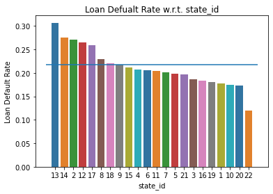

```
          loan_default
state_id
13            0.306587
14            0.275866
2             0.271394
12            0.265558
17            0.258353
8             0.229516
18            0.220126
9             0.217272
15            0.211447
4             0.207171
6             0.205170
11            0.204045
7             0.201739
5             0.198587
21            0.197368
3             0.186191
16            0.182977
19            0.180676
1             0.176978
10            0.174603
20            0.172973
22            0.120000
```

```python
pivot_state = pivot_and_chart('state_id')
print(pivot_state)
```

The state in which a loan is issued looks to have an effect on the default of a loan. State IDs of 13, 14, 2, 12, and 17 seem to have a default rate much higher than average, whereas stated IDs of 3, 16, 19, 1, 10, 20, and 22 have a default rate much lower than the average.

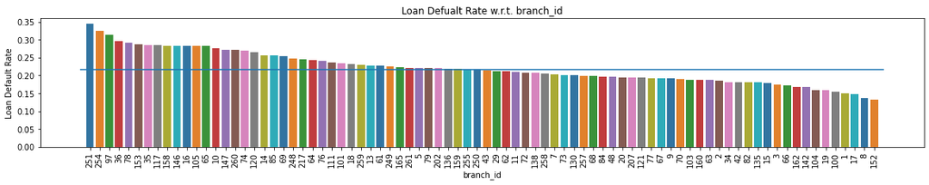

```
           loan_default
branch_id
251            0.343913
254            0.324308
97             0.313625
36             0.296762
78             0.291529
...                 ...
100            0.155015
1              0.149413
17             0.148104
8              0.136999
152            0.133387

[82 rows x 1 columns]
```

```python
plt.rcParams["figure.figsize"] = (20,3) #makes the chart wider to separate the bars enough to distinguish them from each other
plt.xticks(rotation=90) # rotates the branch ids to make them visible in the chart
pivot_branch = pivot_and_chart('branch_id')
plt.rcParams["figure.figsize"] = plt.rcParamsDefault["figure.figsize"] #resetting the width of the figure for future charts
print(pivot_branch)
```

There is some variation in loan default rates between the branches. Some branches such as 251,254 and 97 have loan default rates above 0.3, while others, branches 1, 17, 8, and 152, have loan default rates below 0.15.

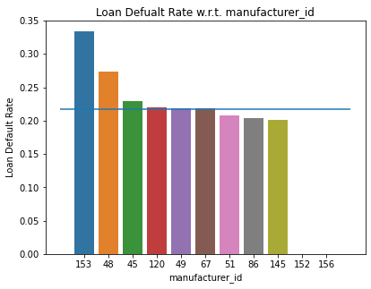

```
                 loan_default
manufacturer_id
153                  0.333333
48                   0.273923
45                   0.228757
120                  0.220309
49                   0.218638
67                   0.218212
51                   0.207671
86                   0.204170
145                  0.201299
152                  0.000000
156                  0.000000
```

```
manufacturer_id
153        12
48      16198
45      55902
120      9523
49      10076
67       2383
51      26932
86     107817
145       770
152         5
156         1
Name: manufacturer_id, dtype: int64
```

```python
pivot_man = pivot_and_chart('manufacturer_id')
print(pivot_man)
auto.manufacturer_id.value_counts()[pivot_man.index]
```

Manufacturer IDs of 153, 152, and 156 have too few loan borrowers to be of any significance. For most of the other manufacturer's, the loan default rate is similar to the population, however, those borrowers that bought a car with manufacturer ID of 48 have a higher likelihood of defaulting than normal.

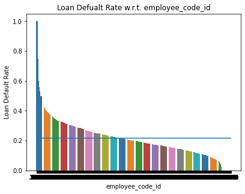

```
                  loan_default
employee_code_id
3795                       1.0
3771                       1.0
3717                       1.0
3685                       1.0
3730                       1.0
...                        ...
3670                       0.0
3049                       0.0
3045                       0.0
3423                       0.0
3619                       0.0

[3269 rows x 1 columns]
```

```python
pivot_employee = pivot_and_chart('employee_code_id')
print(pivot_employee)
```

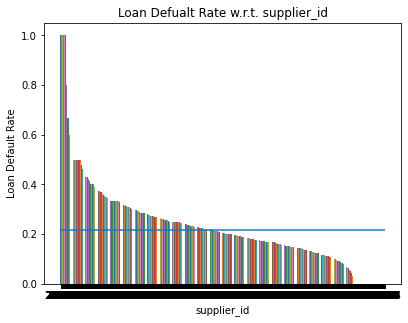

```python
pivot_supplier = pivot_and_chart('supplier_id')
```

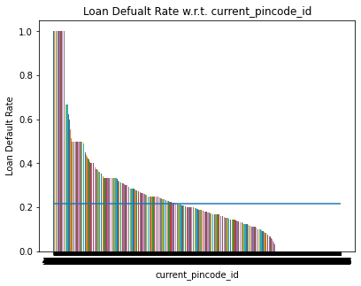

```python
pivot_pin = pivot_and_chart('current_pincode_id')
```

There are too many many unique supplier_id, employee_code_id, and current_pincode_id values for their graphs to be useful to look at specific loan default rate values.

Also, it is unlikely that the pincode a borrower uses or the supplier of the vehicle would affect the outcome of the loan default.

### Loan Defaults with Respect to Employment Type

I want to see the effect of employment type on loan defaults.

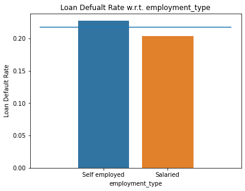

```
                 loan_default
employment_type
Self employed        0.227020
Salaried             0.203686
```

```python
pivot_emp = pivot_and_chart('employment_type')
print(pivot_emp)
```

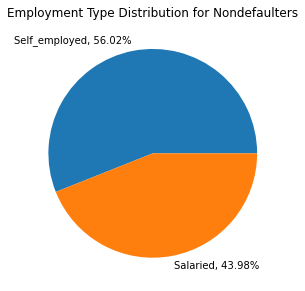

```python
proportions_0_emp_type =auto.loc[auto.loan_default ==0,'employment_type'].value_counts(normalize = True)
self_prop = round(proportions_0_emp_type[0]*100,2)
sal_prop = round(proportions_0_emp_type[1]*100,2)

plt.pie(proportions_0_emp_type,labels=['Self_employed, {}%'.format(self_prop),'Salaried, {}%'.format(sal_prop)])
plt.title('Employment Type Distribution for Nondefaulters')
plt.show()
```

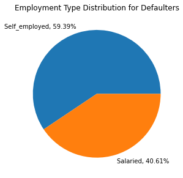

```python
proportions_0_emp_type =auto.loc[auto.loan_default ==1,'employment_type'].value_counts(normalize = True)
self_prop = round(proportions_0_emp_type[0]*100,2)
sal_prop = round(proportions_0_emp_type[1]*100,2)

plt.pie(proportions_0_emp_type,labels=['Self_employed, {}%'.format(self_prop),'Salaried, {}%'.format(sal_prop)])
plt.title('Employment Type Distribution for Defaulters')
plt.show()
```

The distribution of employment type for defaulters has more self employed borrowes. This means self employed auto loan borrowers are at more risk of defaulting. This carries for the entire population, where default rates for self_employed borrowers is 22.7% and 20.4% for salaried borrowers.

### Loan Defaults with respect to Age

I want to see the effect of age on loan defaults.

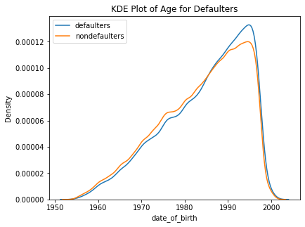

```python
fig = sns.kdeplot(auto.date_of_birth.loc[auto.loan_default==1],label = 'defaulters')
fig = sns.kdeplot(auto.date_of_birth.loc[auto.loan_default==0],label = 'nondefaulters')
plt.title('KDE Plot of Age for Defaulters')
plt.legend()
plt.show()
```

```python
print('Mean birth date of all borrowers:\t',auto.date_of_birth.mean())
print('Mean birth date of defaulters:\t\t',auto.date_of_birth.loc[auto.loan_default==1].mean())
print('Mean birth date of non-defaulters:\t',auto.date_of_birth.loc[auto.loan_default==0].mean())
```

```
Mean birth date of all borrowers:	 1984-02-05 19:02:38.145449600
Mean birth date of defaulters:		 1984-09-30 23:06:53.619481664
Mean birth date of non-defaulters:	 1983-12-01 19:33:33.347570624
```

The overall shape, left skewed, is similar for both kde plots. However, the defaulters have a higher peak of young borrowers than the non defaulters. This is also seen in the higher mean birth date for defaulters.

### Identification Flags

I want to see the effect of identification provided on loan defaults.

```python
only_flag_columns = pd.Series(auto.columns)[pd.Series(auto.columns).str.contains('_flag')==True] #getting only the identification
                                                                                                  #columns
auto[only_flag_columns].describe().loc['mean'].sort_values(ascending = False) #rate of each identification being provided ordered by rate
```

```
aadhar_flag      0.838402
voterid_flag     0.146717
pan_flag         0.076379
driving_flag     0.023461
passport_flag    0.002130
Name: mean, dtype: float64
```

```python
dict_o_flag_defaul_rates = {}
for i in only_flag_columns:
    rates = auto.loan_default.loc[auto[i]==1].value_counts(normalize=True)# getting the loan default rate for each flag column
    dict_o_flag_defaul_rates[i] = rates[1] #storing the name of the flag and rate in a dictionary
flag_default_rates = pd.Series(dict_o_flag_defaul_rates) #making a series out of the dictionary
```

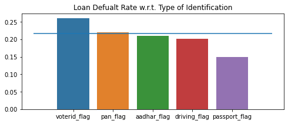

```python
plt.rcParams["figure.figsize"] = (8,3) #makes the chart wider to separate the bars enough to distinguish their labels from each other

sns.barplot(flag_default_rates.index,flag_default_rates,order= flag_default_rates.sort_values(ascending = False).index,palette = sns.color_palette())
#plotting the rates in descending order
len_cat =flag_default_rates.shape[0] #getting the length of the horizontal line
plt.hlines(auto.loan_default.mean(),xmin=-1,xmax=len_cat,label='average loan default') #average loan default line plotted

plt.title('Loan Defualt Rate w.r.t. Type of Identification')
plt.show()
plt.rcParams["figure.figsize"] = plt.rcParamsDefault["figure.figsize"] #resetting the width of the figure for future charts
```

Most borrowers gave their aadhar number as their identification. Passports were provided the least. If the loan default rate is calculated for each type of identification, borrowers that provided voterid were more likely than average to default on their loan, while those that provided a passport were less likely to default.

# (Week 3 Tasks Start Here)

### Loan Default w.r.t Credit Bureau Score

I want to see the difference in range, mean, and distribution of credit bureau scores between defaulters and nondefaulters.

```python
print(auto.perform_cns_score.value_counts().sort_index()) #viewing the range,some of the distribution,and the mean of the
                                                          #perform_cns_score variable for all borrowers
print()
print('mean of all:', auto.perform_cns_score.mean())
```

```
0      114765
11          3
14        965
15       3716
16       2851
        ...
873         9
878         7
879        59
884         1
890         4
Name: perform_cns_score, Length: 573, dtype: int64

mean of all: 290.56715254399677
```

```python
print(auto.perform_cns_score.loc[auto.loan_default==0].value_counts().sort_index()) #viewing the range,some of the distribution,
                                                                                    #and the mean of the perform_cns_score
                                                                                    #variable for nondefaulters
print()
print('mean of non_defaulters:', auto.perform_cns_score.loc[auto.loan_default==0].mean())
```

```
0      88205
11         3
14       758
15      2764
16      2330
       ...
873        6
878        7
879       54
884        1
890        4
Name: perform_cns_score, Length: 572, dtype: int64

mean of non_defaulters: 300.99657968499736
```

```python
print(auto.perform_cns_score.loc[auto.loan_default==1].value_counts().sort_index()) #viewing the range,some of the distribution,
                                                                                    #and the mean of the perform_cns_score
                                                                                    #variable for defaulters
print()
print('mean of defaulters:', auto.perform_cns_score.loc[auto.loan_default==1].mean())
```

```
0      26560
14       207
15       952
16       521
17       756
       ...
858        2
862        1
870        6
873        3
879        5
Name: perform_cns_score, Length: 537, dtype: int64

mean of defaulters: 252.91895364477725
```

I can see that the range for defaulters is smaller than that of nondefaulters. Also, the average score for defaulters is lower than that of non defaulters.

I wanted to see why there were so many low scores in perform_cns_score and if they corresponded to anything found in the perform_cns_score_description variable. I found the mean and std of the score variable for each category in score_description to find any patterns or insights.

```python
auto.perform_cns_score_description.value_counts()
```

```
No Bureau History Available                                114765
C-Very Low Risk                                             15878
A-Very Low Risk                                             13958
D-Very Low Risk                                             11230
B-Very Low Risk                                              9105
M-Very High Risk                                             8684
F-Low Risk                                                   8375
K-High Risk                                                  8180
H-Medium Risk                                                6778
E-Low Risk                                                   5748
I-Medium Risk                                                5491
G-Low Risk                                                   3937
Not Scored: Sufficient History Not Available                 3716
J-High Risk                                                  3703
Not Scored: Not Enough Info available on the customer        3610
Not Scored: No Activity seen on the customer (Inactive)      2851
Not Scored: No Updates available in last 36 months           1515
L-Very High Risk                                             1127
Not Scored: Only a Guarantor                                  965
Not Scored: More than 50 active Accounts found                  3
Name: perform_cns_score_description, dtype: int64
```

```python
for i in auto.perform_cns_score_description.value_counts().index: #getting the mean and std of all the categories in the
                                                                  #perform_cns_score_description variable
    print(i)
    print(auto.loc[auto.perform_cns_score_description==i,'perform_cns_score'].mean())
    print(auto.loc[auto.perform_cns_score_description==i,'perform_cns_score'].std())
    print()
```

```
No Bureau History Available
0.0
0.0

C-Very Low Risk
741.9103161607255
6.7805295082846575

A-Very Low Risk
827.6622725318814
8.804093900403366

D-Very Low Risk
715.9422083704363
8.842158370443363

B-Very Low Risk
774.1724327292696
11.813249542035813

M-Very High Risk
300.0
0.0

F-Low Risk
666.0692537313433
10.148714082108539

K-High Risk
440.6408312958435
45.11940762208292

H-Medium Risk
617.0357037474181
8.319957035112802

E-Low Risk
691.5342727905359
7.6849194187698595

```

[output cut: 24 more lines]

```
Not Scored: No Updates available in last 36 months
18.0
0.0

L-Very High Risk
326.5776397515528
15.137233584953764

Not Scored: Only a Guarantor
14.0
0.0

Not Scored: More than 50 active Accounts found
11.0
0.0
```

It looks like the 'Not Scored' values in the score_description variable were encoded to specific numbers in the score variable. These should all be 0 so I will be changing them all. Also, so long as the score_description variable is kept, this encoding is not necessary.

Another observation that can be made from the these values is that 300 is the minimum credit score for anyone that has a credit score. This is seen from the M-Very High Risk category having a mean of 300 and standard deviation of 0 with 8684 observations.

```python
score_decription_categories = pd.Series(auto.perform_cns_score_description.value_counts().index) #turning categories of
                                                                                                 #score_description into a Series
not_score_description_rows = score_decription_categories[score_decription_categories.str.contains('Not')] #grabbing all the
                                                                                                             #'Not Scored' categories

for i in not_score_description_rows: #replacing the score for any 'Not Scored' categories with 0
    auto.loc[auto.perform_cns_score_description==i,'perform_cns_score'] = 0
```

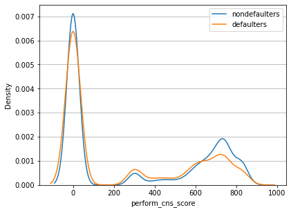

```python
fig = sns.kdeplot(auto.perform_cns_score.loc[auto.loan_default==0],label='nondefaulters')
fig = sns.kdeplot(auto.perform_cns_score.loc[auto.loan_default==1],label='defaulters')
plt.grid(True,axis='y') #putting in horizontal gridlines
plt.legend()
plt.show()
```

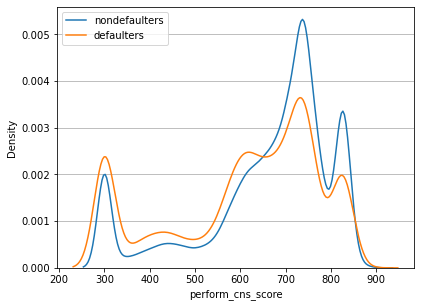

```python
fig = sns.kdeplot(auto.perform_cns_score.loc[auto.loan_default==0].loc[auto.perform_cns_score!=0],label='nondefaulters')
fig = sns.kdeplot(auto.perform_cns_score.loc[auto.loan_default==1].loc[auto.perform_cns_score!=0],label='defaulters')

plt.grid(True,axis='y') #putting in horizontal gridlines
plt.legend()
plt.show()
```

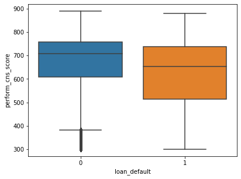

```python
sns.boxplot(x= 'loan_default', y = 'perform_cns_score',data =auto.loc[auto.perform_cns_score!=0])
```

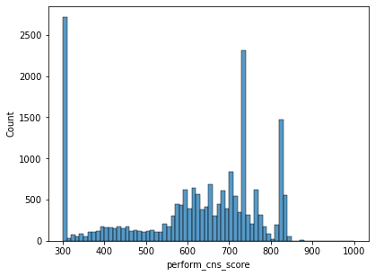

```python
sns.histplot(auto.perform_cns_score.loc[auto.loan_default==1],bins = np.linspace(300,1000,71))
plt.show()
```

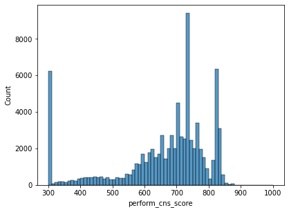

```python
sns.histplot(auto.perform_cns_score.loc[auto.loan_default==0],bins = np.linspace(300,1000,71))
plt.show()
```

When looking at the histograms for defaulters and nondefaulters with credit scores the shapes are similar. However, defaulters have the lowest score, 300, as their mode, wheras nondefaulters have a mode in the 700s.The higher density above a score of 650 for nondefaulters can also be seen with more of the bins being filled in the range of 600 to 800.

### Primary Details

I want to see how the primary account details differ between defaulters and nondefaulters. To do this, I will be plotting the distribution of each primary account detail for defaulters and nondefaulters. I would also like to see how the means and standard deviation differ between defaulters and nondefaulters.

```python
def account_info(i,pri_or_sec): #nothing is returned, it only displays things

    ####Function History
    #This was a for loop first, but I turned it into a function instead. That's why it might look weird or inefficient.
    #Some of this code looks like it is only for the primary account, but it works for secondary as well.
    #I just don't want to have to go thru and rename a bunch of stuff. I can also make it more efficient by
    #focusing on a single column from the start, but again, I'd rather not at this time.

    ####Variable Description
    #i can only be between 0 and 6.
    #pri_or_sec can take more than pri or sec, but that is what I made the function for

    #getting the correct columns with pri_or_sec
    primary_account_cols = pd.Series(auto.columns).str.contains(pri_or_sec) #boolean mask for the primary account detail columns
    primary_account_info = auto.loc[:,list(primary_account_cols)] #primary account columns only dataframe

    #describe() information
    new_df = pd.concat([pd.DataFrame(primary_account_info.describe().iloc[1:,i]), #getting the describe() output for each primary account column
              primary_account_info.loc[auto.loan_default==0].describe().iloc[1:,i], #getting the describe() output for each primary account column for defaulters
              primary_account_info.loc[auto.loan_default==1].describe().iloc[1:,i]],axis=1) #getting the describe() output for each primary account column for nondefaulters
    #putting all the above information into one dataframe
    new_df.columns = [pd.DataFrame(primary_account_info.describe().iloc[1:,i]).columns[0]+'_all', #changing column names
                     pd.DataFrame(primary_account_info.describe().iloc[1:,i]).columns[0]+'_nondefaulter',
                     pd.DataFrame(primary_account_info.describe().iloc[1:,i]).columns[0]+'_defaulter']
    display(new_df)

    #boxplot
    sns.boxplot(x= 'loan_default', y = primary_account_info.columns[i],data =auto.loc[auto[primary_account_info.columns[i]]!=0])
    if auto[primary_account_info.columns[i]].loc[auto[primary_account_info.columns[i]]!=0].mean()>10:
        plt.yscale('log') #switching to log scale for those columns that need it
    plt.title('Loan Default vs {}'.format(primary_account_info.columns[i]))
    plt.show()

    #kdeplot
    fig = sns.kdeplot(auto[primary_account_info.columns[i]].loc[auto.loan_default==0].loc[auto[primary_account_info.columns[i]]!=0],label='nondefaulters')
    fig = sns.kdeplot(auto[primary_account_info.columns[i]].loc[auto.loan_default==1].loc[auto[primary_account_info.columns[i]]!=0],label='defaulters')
    plt.grid(True,axis='y') #putting in horizontal gridlines
    plt.legend()
    if auto[primary_account_info.columns[i]].loc[auto[primary_account_info.columns[i]]!=0].mean()>10:
        plt.xscale('log') #switching to log scale for those columns that need it
    plt.title('Loan Default vs {}'.format(primary_account_info.columns[i]))
    plt.show()
```

|  | pri_no_of_accts_all | pri_no_of_accts_nondefaulter | pri_no_of_accts_defaulter |
| --- | --- | --- | --- |
| mean | 2.443117 | 2.540221 | 2.092590 |
| std | 5.206574 | 5.246757 | 5.043387 |
| min | 0.000000 | 0.000000 | 0.000000 |
| 25% | 0.000000 | 0.000000 | 0.000000 |
| 50% | 1.000000 | 1.000000 | 0.000000 |
| 75% | 3.000000 | 3.000000 | 2.000000 |
| max | 453.000000 | 354.000000 | 453.000000 |

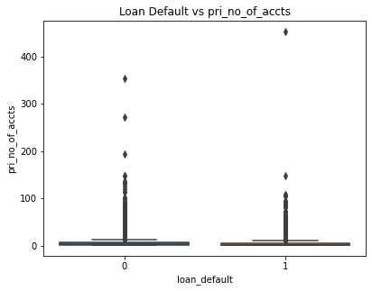

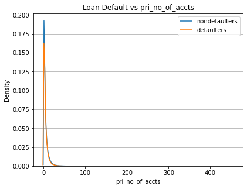

```python
account_info(0,'pri') #no_of accounts details
```

|  | pri_active_accts_all | pri_active_accts_nondefaulter | pri_active_accts_defaulter |
| --- | --- | --- | --- |
| mean | 1.043603 | 1.086175 | 0.889924 |
| std | 1.943693 | 2.010475 | 1.671708 |
| min | 0.000000 | 0.000000 | 0.000000 |
| 25% | 0.000000 | 0.000000 | 0.000000 |
| 50% | 0.000000 | 0.000000 | 0.000000 |
| 75% | 1.000000 | 1.000000 | 1.000000 |
| max | 144.000000 | 144.000000 | 35.000000 |

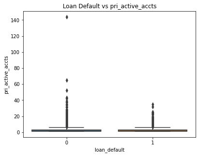

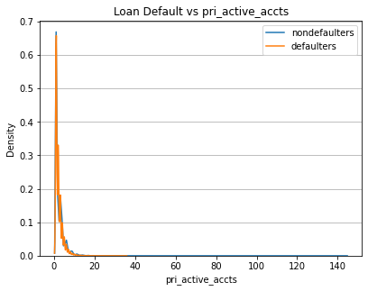

```python
account_info(1,'pri') #no. of active accounts details
```

|  | pri_overdue_accts_all | pri_overdue_accts_nondefaulter | pri_overdue_accts_defaulter |
| --- | --- | --- | --- |
| mean | 0.157326 | 0.145572 | 0.199755 |
| std | 0.550317 | 0.533602 | 0.604946 |
| min | 0.000000 | 0.000000 | 0.000000 |
| 25% | 0.000000 | 0.000000 | 0.000000 |
| 50% | 0.000000 | 0.000000 | 0.000000 |
| 75% | 0.000000 | 0.000000 | 0.000000 |
| max | 25.000000 | 25.000000 | 18.000000 |

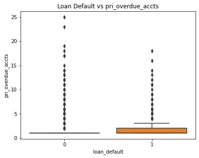

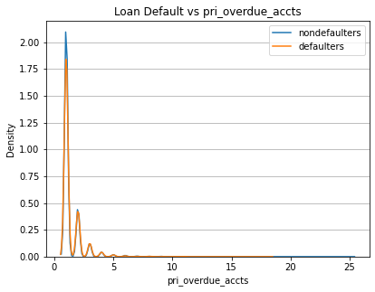

```python
account_info(2,'pri') #no of overdue accounts details
```

The means for number of accounts and number of active accounts was higher for nondefaulters, while the mean for number of overdue accounts was lower for nondefaulters. This make sense since defaulters wouldn't be trusted with more loans, and if you are overdue on an account you will most likely have a hard time paying for another loan. However, since there were many outliers in the data, the mean may not a good measure to use.

The distributions seen from the box and kde plots are similar for both defaulters and nondefaulters for all these variables. The nondefaulters have higher peaks near 0, and they also had the larger number of high outliers.

|  | pri_current_balance_all | pri_current_balance_nondefaulter | pri_current_balance_defaulter |
| --- | --- | --- | --- |
| mean | 1.666006e+05 | 1.801832e+05 | 1.175699e+05 |
| std | 9.439467e+05 | 9.958525e+05 | 7.242361e+05 |
| min | 0.000000e+00 | 0.000000e+00 | 0.000000e+00 |
| 25% | 0.000000e+00 | 0.000000e+00 | 0.000000e+00 |
| 50% | 0.000000e+00 | 0.000000e+00 | 0.000000e+00 |
| 75% | 3.540800e+04 | 3.869000e+04 | 2.595450e+04 |
| max | 9.652492e+07 | 9.652492e+07 | 4.505116e+07 |

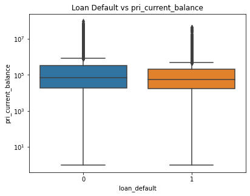

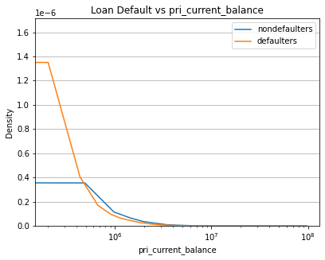

```python
account_info(3,'pri') # current balance details
```

Defaulters look to have a lower current balance than nondefaulter. This may be because they were viewed as riskier and do not have much success in aquiring loans.

|  | pri_sanctioned_amount_all | pri_sanctioned_amount_nondefaulter | pri_sanctioned_amount_defaulter |
| --- | --- | --- | --- |
| mean | 2.193242e+05 | 2.334337e+05 | 1.683919e+05 |
| std | 2.390504e+06 | 1.237984e+06 | 4.561513e+06 |
| min | 0.000000e+00 | 0.000000e+00 | 0.000000e+00 |
| 25% | 0.000000e+00 | 0.000000e+00 | 0.000000e+00 |
| 50% | 0.000000e+00 | 0.000000e+00 | 0.000000e+00 |
| 75% | 6.300000e+04 | 7.000000e+04 | 5.000000e+04 |
| max | 1.000000e+09 | 1.058657e+08 | 1.000000e+09 |

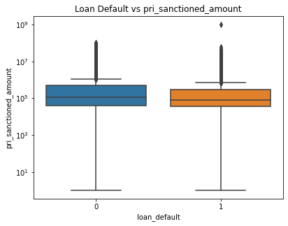

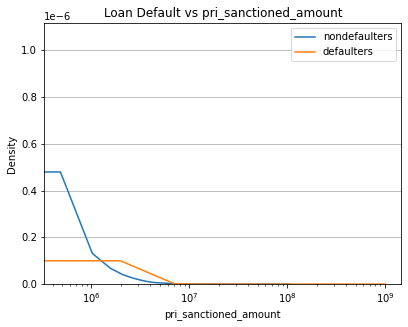

```python
account_info(4,'pri') #sanctioned amount details
```

|  | pri_disbursed_amount_all | pri_disbursed_amount_nondefaulter | pri_disbursed_amount_defaulter |
| --- | --- | --- | --- |
| mean | 2.188602e+05 | 2.327915e+05 | 1.685709e+05 |
| std | 2.393450e+06 | 1.243850e+06 | 4.562882e+06 |
| min | 0.000000e+00 | 0.000000e+00 | 0.000000e+00 |
| 25% | 0.000000e+00 | 0.000000e+00 | 0.000000e+00 |
| 50% | 0.000000e+00 | 0.000000e+00 | 0.000000e+00 |
| 75% | 6.124450e+04 | 6.723700e+04 | 5.000000e+04 |
| max | 1.000000e+09 | 1.057557e+08 | 1.000000e+09 |

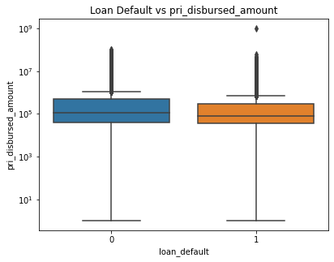

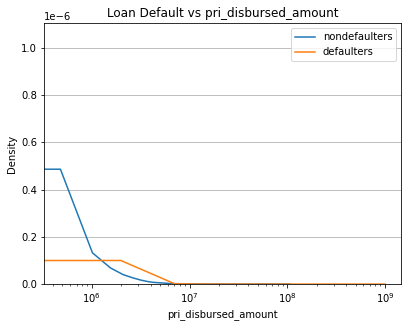

```python
account_info(5,'pri') #disbursed amount details
```

Disbursed amount and sanctioned amount are similar to current balance in that nondefaulters had a higher mean than defaulters. This is probably due to the how risky the borrower was determined to be.

The sanctioned and disbursed amounr variables look to have very similary distributions and means. I would like to investigate this further.

```python
print((auto.pri_disbursed_amount == auto.pri_sanctioned_amount).sum())
print(auto.shape[0])
print((auto.pri_disbursed_amount == auto.pri_sanctioned_amount).sum()/auto.shape[0])
anova_test(auto.pri_disbursed_amount,auto.pri_sanctioned_amount)
```

```
216099
229619
0.9411198550642587
```

```
F_onewayResult(statistic=0.004321290133089229, pvalue=0.9475876247912395)
```

It looks like 216099 borrowers out of the total 229619 had the same sanctioned amount as disbursed amount. That is a 94% match in values. An ANOVA test also finds that the mean of the two groups are very similar, giving a p value of 0.94.

|  | primary_instal_amt_all | primary_instal_amt_nondefaulter | primary_instal_amt_defaulter |
| --- | --- | --- | --- |
| mean | 1.286165e+04 | 1.366534e+04 | 9.960494e+03 |
| std | 1.486026e+05 | 1.544867e+05 | 1.250385e+05 |
| min | 0.000000e+00 | 0.000000e+00 | 0.000000e+00 |
| 25% | 0.000000e+00 | 0.000000e+00 | 0.000000e+00 |
| 50% | 0.000000e+00 | 0.000000e+00 | 0.000000e+00 |
| 75% | 2.000000e+03 | 2.047000e+03 | 1.867500e+03 |
| max | 2.564281e+07 | 2.564281e+07 | 1.542041e+07 |

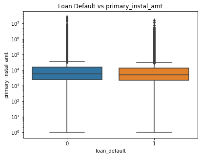

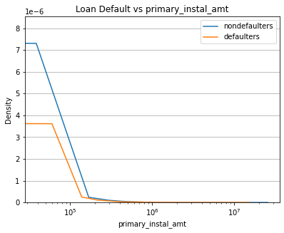

```python
account_info(6,'pri') #installmeant amount details
```

The installment amount was lower for defaulters than non defaulters. Since the installment amount is most likely a function of disbursal amount, which would be lower for defaulters, this makes sense.

### Secondary Details

I want to see if the the secondary account details follow the same patterns as the primary account details.

|  | sec_no_of_accts_all | sec_no_of_accts_nondefaulter | sec_no_of_accts_defaulter |
| --- | --- | --- | --- |
| mean | 0.059516 | 0.062261 | 0.049608 |
| std | 0.629451 | 0.654075 | 0.531037 |
| min | 0.000000 | 0.000000 | 0.000000 |
| 25% | 0.000000 | 0.000000 | 0.000000 |
| 50% | 0.000000 | 0.000000 | 0.000000 |
| 75% | 0.000000 | 0.000000 | 0.000000 |
| max | 52.000000 | 52.000000 | 38.000000 |

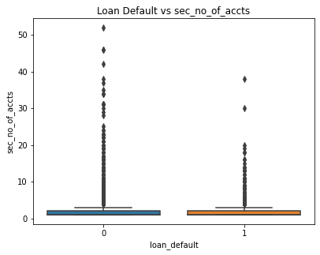

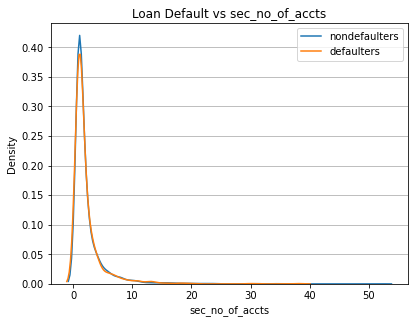

|  | sec_active_accts_all | sec_active_accts_nondefaulter | sec_active_accts_defaulter |
| --- | --- | --- | --- |
| mean | 0.027916 | 0.028897 | 0.024372 |
| std | 0.317089 | 0.324158 | 0.290117 |
| min | 0.000000 | 0.000000 | 0.000000 |
| 25% | 0.000000 | 0.000000 | 0.000000 |
| 50% | 0.000000 | 0.000000 | 0.000000 |
| 75% | 0.000000 | 0.000000 | 0.000000 |
| max | 36.000000 | 36.000000 | 22.000000 |

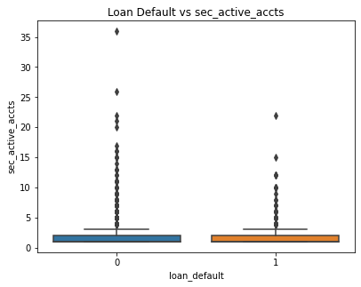

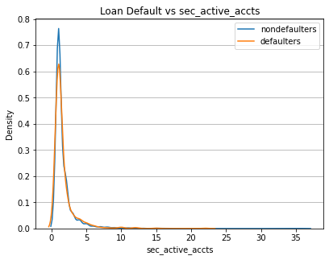

|  | sec_overdue_accts_all | sec_overdue_accts_nondefaulter | sec_overdue_accts_defaulter |
| --- | --- | --- | --- |
| mean | 0.007308 | 0.007391 | 0.007006 |
| std | 0.111638 | 0.111843 | 0.110896 |
| min | 0.000000 | 0.000000 | 0.000000 |
| 25% | 0.000000 | 0.000000 | 0.000000 |
| 50% | 0.000000 | 0.000000 | 0.000000 |
| 75% | 0.000000 | 0.000000 | 0.000000 |
| max | 8.000000 | 8.000000 | 6.000000 |

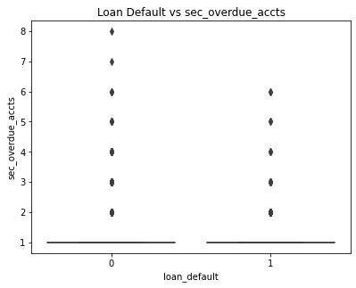

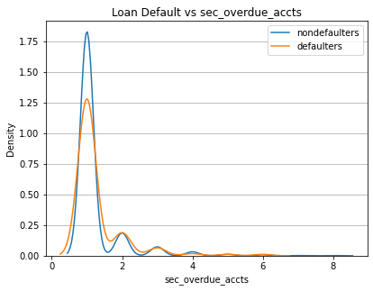

|  | sec_current_balance_all | sec_current_balance_nondefaulter | sec_current_balance_defaulter |
| --- | --- | --- | --- |
| mean | 5.494898e+03 | 5.993200e+03 | 3.696123e+03 |
| std | 1.714354e+05 | 1.853795e+05 | 1.068914e+05 |
| min | 0.000000e+00 | 0.000000e+00 | 0.000000e+00 |
| 25% | 0.000000e+00 | 0.000000e+00 | 0.000000e+00 |
| 50% | 0.000000e+00 | 0.000000e+00 | 0.000000e+00 |
| 75% | 0.000000e+00 | 0.000000e+00 | 0.000000e+00 |
| max | 3.603285e+07 | 3.603285e+07 | 1.071604e+07 |

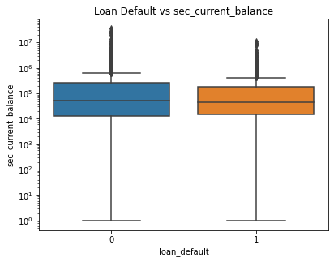

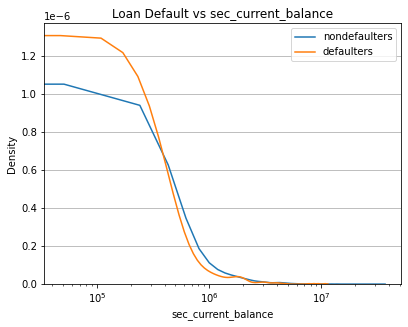

|  | sec_sanctioned_amount_all | sec_sanctioned_amount_nondefaulter | sec_sanctioned_amount_defaulter |
| --- | --- | --- | --- |
| mean | 7.378100e+03 | 7.992940e+03 | 5.158647e+03 |
| std | 1.844536e+05 | 1.965643e+05 | 1.317580e+05 |
| min | 0.000000e+00 | 0.000000e+00 | 0.000000e+00 |
| 25% | 0.000000e+00 | 0.000000e+00 | 0.000000e+00 |
| 50% | 0.000000e+00 | 0.000000e+00 | 0.000000e+00 |
| 75% | 0.000000e+00 | 0.000000e+00 | 0.000000e+00 |
| max | 3.000000e+07 | 3.000000e+07 | 1.190000e+07 |

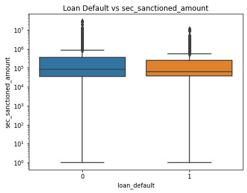

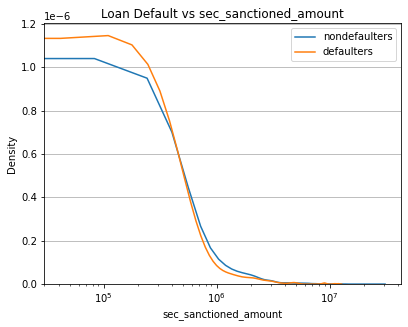

|  | sec_disbursed_amount_all | sec_disbursed_amount_nondefaulter | sec_disbursed_amount_defaulter |
| --- | --- | --- | --- |
| mean | 7.259823e+03 | 7.862264e+03 | 5.085125e+03 |
| std | 1.838852e+05 | 1.959442e+05 | 1.314304e+05 |
| min | 0.000000e+00 | 0.000000e+00 | 0.000000e+00 |
| 25% | 0.000000e+00 | 0.000000e+00 | 0.000000e+00 |
| 50% | 0.000000e+00 | 0.000000e+00 | 0.000000e+00 |
| 75% | 0.000000e+00 | 0.000000e+00 | 0.000000e+00 |
| max | 3.000000e+07 | 3.000000e+07 | 1.190000e+07 |

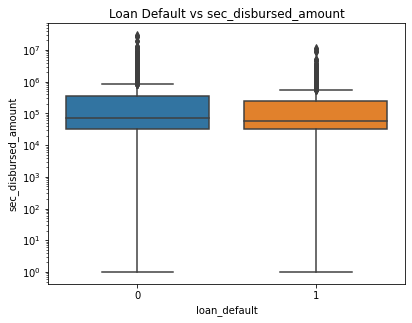

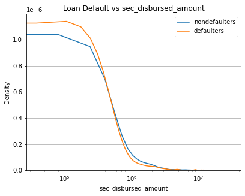

|  | sec_instal_amt_all | sec_instal_amt_nondefaulter | sec_instal_amt_defaulter |
| --- | --- | --- | --- |
| mean | 3.211561e+02 | 3.321033e+02 | 2.816386e+02 |
| std | 1.561740e+04 | 1.664721e+04 | 1.113387e+04 |
| min | 0.000000e+00 | 0.000000e+00 | 0.000000e+00 |
| 25% | 0.000000e+00 | 0.000000e+00 | 0.000000e+00 |
| 50% | 0.000000e+00 | 0.000000e+00 | 0.000000e+00 |
| 75% | 0.000000e+00 | 0.000000e+00 | 0.000000e+00 |
| max | 4.170901e+06 | 4.170901e+06 | 1.447600e+06 |

[2 more figures not shown]

```python
for i in range(7):
    account_info(i,'sec') #secondary account details
```

Most of the patterns for primary accounts hold true for secondary accounts, however, the magnitude in differences between the means were smaller.

The only pattern that was opposite was for overdue accounts. Another difference is that all the mean values were lower for the secondary details.

## Credit History Details

I want to see how number of inquiries effects Loan Defaults

### Loan Defaults wrt Number of Inquiries

|  | no_of_inquiries_all | no_of_inquiries_nondefaulter | no_of_inquiries_defaulter |
| --- | --- | --- | --- |
| mean | 0.207069 | 0.190792 | 0.265825 |
| std | 0.707164 | 0.666068 | 0.836303 |
| min | 0.000000 | 0.000000 | 0.000000 |
| 25% | 0.000000 | 0.000000 | 0.000000 |
| 50% | 0.000000 | 0.000000 | 0.000000 |
| 75% | 0.000000 | 0.000000 | 0.000000 |
| max | 36.000000 | 36.000000 | 19.000000 |

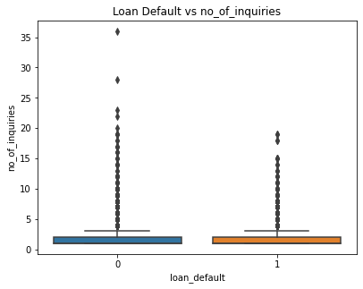

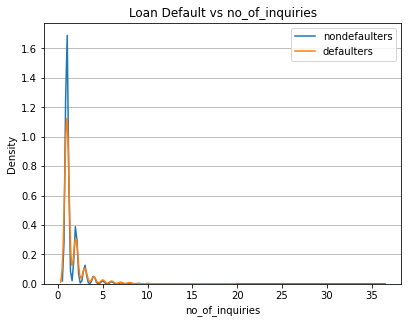

```python
account_info(0,'no_of_inquiries') # number of inqueries information
```

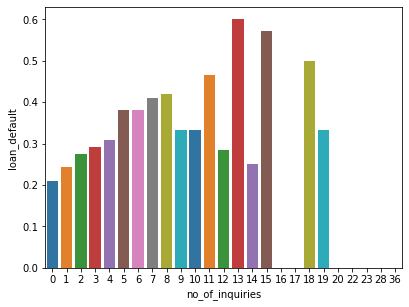

```
                 loan_default
no_of_inquiries
0                    0.210614
1                    0.243414
2                    0.275403
3                    0.292529
4                    0.309840
5                    0.382090
6                    0.382353
7                    0.410448
8                    0.419048
9                    0.333333
10                   0.333333
11                   0.466667
12                   0.285714
13                   0.600000
14                   0.250000
15                   0.571429
16                   0.000000
17                   0.000000
18                   0.500000
19                   0.333333
20                   0.000000
22                   0.000000
23                   0.000000
28                   0.000000
36                   0.000000
```

```python
inq_def_pivot = pd.pivot_table(auto,values='loan_default',index='no_of_inquiries')
categories = inq_def_pivot.index
loan_default_averages = inq_def_pivot.iloc[:,0]
sns.barplot(categories,loan_default_averages,palette = sns.color_palette())
plt.show()
print(inq_def_pivot)
```

It can be seen that defaulters on average have more inquiries than nondefaulters, and this is despite nondefaulters having the larger outliers. A plot of the number of inqueries vs the loan default rate shows that from 0 to 8 inqueries, the loan defeault rate steadily rises.

## Getting Data Ready for Logistic Regression

Before the data is manipulated for logistic regression, I want to export it back to as a csv for use in Tableau.

auto_copy = auto.copy() auto_copy.to_csv(r'C:\Users\Xavier\Downloads\programming\simplilearn\Live_classes\PG DA - Data Analyst Capstone\2_auto_loan_defaulters\auto_loan_data.csv', index = False)

All variables need to be converted to numerical to perform logistic regression. That means I need to turn non-float and non-int to dummy variables, turn them into numerical if possible, or drop them if they are unneeded.

```python
auto.info()
```

```
<class 'pandas.core.frame.DataFrame'>
Int64Index: 229619 entries, 0 to 233153
Data columns (total 40 columns):
 #   Column                               Non-Null Count   Dtype
---  ------                               --------------   -----
 0   unique_id                            229619 non-null  int64
 1   disbursed_amount                     229619 non-null  int64
 2   asset_cost                           229619 non-null  int64
 3   ltv                                  229619 non-null  float64
 4   branch_id                            229619 non-null  int64
 5   supplier_id                          229619 non-null  int64
 6   manufacturer_id                      229619 non-null  int64
 7   current_pincode_id                   229619 non-null  int64
 8   date_of_birth                        229619 non-null  datetime64[ns]
 9   employment_type                      229619 non-null  object
```

[output cut: 32 more lines]

From looking at the info() for auto, I need to change perform_cns_score_description and employment_type into a dummy variable or drop them, and I need to turn average_acct_age and credit_history_length into numerical values. For the datetime variables, I will subtract them to get an age variable and drop the date_of_birth and disbursal_date.

### Account Age and Credit HIstory Length into Numerical Values

```python
average_age = auto.average_acct_age.str.extract('([0-9]+)[a-z]* ([0-9]+)') #extracting the year and month into a new dataframe
auto.average_acct_age = average_age.iloc[:,0].astype('int64')+average_age.iloc[:,1].astype('int64')/12 #adding the year and month/12
                                                                                                       #then reassigning it to
                                                                                                       #average_acct_age
```

```python
credit_length = auto.credit_history_length.str.extract('([0-9]+)[a-z]* ([0-9]+)')
auto.credit_history_length = credit_length.iloc[:,0].astype('int64')+credit_length.iloc[:,1].astype('int64')/12
```

```python
auto.iloc[:,36:38].info()
```

```
<class 'pandas.core.frame.DataFrame'>
Int64Index: 229619 entries, 0 to 233153
Data columns (total 2 columns):
 #   Column                 Non-Null Count   Dtype
---  ------                 --------------   -----
 0   average_acct_age       229619 non-null  float64
 1   credit_history_length  229619 non-null  float64
dtypes: float64(2)
memory usage: 13.3 MB
```

### Score Description Dummy Variables

Since the CNS score description is linked to the CNS score, I will be dropping the score descroption variable since there will be no lost meaning.

```python
auto = auto.drop('perform_cns_score_description',axis=1)
```

### Employment Type Dummy Variables

```python
auto = pd.get_dummies(auto,columns=['employment_type'])
```

### Datetime Variables

```python
auto['age'] = -((auto.date_of_birth - auto.disbursal_date).dt.days)
```

```python
auto.age
```

```
0         12633
1         12030
2         14901
3         11071
4          8852
          ...
233149    13479
233150     9512
233151    13457
233152    10609
233153    18320
Name: age, Length: 229619, dtype: int64
```

## Logistic Regression Model

I will be splitting my dataset into a train set,75%, and test set, 25%. From there, I will make the model and check its accuracy.

```python
np.random.seed(1) #setting the random seed for reproducibility
```

```python
auto_train,auto_test = train_test_split(auto.drop(['unique_id','date_of_birth','disbursal_date'],axis=1))
#split the set into train and test segments
#I have also dropped the unique_id, date_of_birth, and disbursal_date columns
```

```python
y_train = auto_train.loan_default #target variable
x_train = auto_train.drop('loan_default',axis=1) #independent variables

y_test = auto_test.loan_default
x_test = auto_test.drop('loan_default',axis=1)
```

```python
log_reg = LogisticRegression() #initiating the logistic regression object

log_reg.fit(x_train,y_train) #fitting the data into the model
log_reg.score(x_test,y_test) #checking the accuracy of the model on the test data
```

```
0.7824579740440728
```

```python
confusion_matrix(y_test,log_reg.predict(x_test)) #generating a confusion matrix from the model
```

```
array([[44917,     0],
       [12488,     0]], dtype=int64)
```

```python
tn, fp, fn, tp = confusion_matrix(y_test,log_reg.predict(x_test)).ravel()
(tn + tp)/(tn+tp+fn+fp) #checking the accuracy of the .score() function
```

```
0.7824579740440728
```

The model showed that all the loans in the test set would not default. This gave an accuracy of 78.24% with 44917 true negatives, 12488 false negatives, and 0 true positives and false positives. This model is ok and seems to be similar to the one the bank already uses to determine if a borrower should get a loan or not.

## Significance of Variables

I want to know which variables were significant to my model and which were not.

```python
glm_binom = sm.GLM(y_train, x_train, family=sm.families.Binomial())
res = glm_binom.fit()
print(res.summary())
```

```
                 Generalized Linear Model Regression Results
==============================================================================
Dep. Variable:           loan_default   No. Observations:               172214
Model:                            GLM   Df Residuals:                   172177
Model Family:                Binomial   Df Model:                           36
Link Function:                  logit   Scale:                          1.0000
Method:                          IRLS   Log-Likelihood:                -86932.
Date:                Fri, 02 Jul 2021   Deviance:                   1.7386e+05
Time:                        19:23:46   Pearson chi2:                 1.74e+05
No. Iterations:                     6
Covariance Type:            nonrobust
=======================================================================================================
                                          coef    std err          z      P>|z|      [0.025      0.975]
-------------------------------------------------------------------------------------------------------
disbursed_amount                    -4.661e-06   2.69e-06     -1.732      0.083   -9.94e-06    6.14e-07
asset_cost                           8.529e-06   1.82e-06      4.699      0.000    4.97e-06    1.21e-05
ltv                                     0.0364      0.002     17.036      0.000       0.032       0.041
branch_id                               0.0003   8.74e-05      3.788      0.000       0.000       0.001
supplier_id                          7.951e-06   1.83e-06      4.355      0.000    4.37e-06    1.15e-05
manufacturer_id                        -0.0033      0.000    -12.002      0.000      -0.004      -0.003
current_pincode_id                   3.082e-05   3.09e-06      9.983      0.000    2.48e-05    3.69e-05
state_id                                0.0237      0.001     17.156      0.000       0.021       0.026
employee_code_id                     4.016e-05   6.21e-06      6.471      0.000     2.8e-05    5.23e-05
aadhar_flag                            -0.1806      0.047     -3.857      0.000      -0.272      -0.089
pan_flag                               -0.0852      0.023     -3.661      0.000      -0.131      -0.040
voterid_flag                            0.0441      0.046      0.965      0.334      -0.045       0.134
driving_flag                           -0.1642      0.055     -2.962      0.003      -0.273      -0.056
passport_flag                          -0.4977      0.151     -3.304      0.001      -0.793      -0.202
perform_cns_score                      -0.0003   2.35e-05    -12.083      0.000      -0.000      -0.000
pri_no_of_accts                        -0.0045      0.002     -2.203      0.028      -0.009      -0.000
pri_active_accts                       -0.0500      0.008     -6.347      0.000      -0.065      -0.035
pri_overdue_accts                       0.2702      0.014     19.879      0.000       0.244       0.297
pri_current_balance                  5.112e-08    3.4e-08      1.502      0.133   -1.56e-08    1.18e-07
pri_sanctioned_amount               -8.601e-09   1.07e-07     -0.081      0.936   -2.18e-07    2.01e-07
pri_disbursed_amount                -1.346e-07    1.1e-07     -1.222      0.222    -3.5e-07    8.12e-08
sec_no_of_accts                        -0.0141      0.020     -0.715      0.475      -0.053       0.025
sec_active_accts                        0.0061      0.042      0.143      0.886      -0.077       0.089
sec_overdue_accts                       0.0009      0.067      0.014      0.989      -0.130       0.132
sec_current_balance                  6.994e-08   1.11e-07      0.631      0.528   -1.47e-07    2.87e-07
sec_sanctioned_amount               -1.528e-06   1.65e-06     -0.924      0.356   -4.77e-06    1.71e-06
sec_disbursed_amount                 1.404e-06   1.66e-06      0.849      0.396   -1.84e-06    4.65e-06
primary_instal_amt                   3.946e-08   4.47e-08      0.883      0.377   -4.81e-08    1.27e-07
sec_instal_amt                       3.626e-07    3.5e-07      1.037      0.300   -3.23e-07    1.05e-06
new_accts_in_last_six_months            0.0046      0.011      0.420      0.675      -0.017       0.026
delinquent_accts_in_last_six_months     0.2929      0.018     16.345      0.000       0.258       0.328
average_acct_age                        0.0965      0.010      9.586      0.000       0.077       0.116
credit_history_length                  -0.0741      0.007    -11.248      0.000      -0.087      -0.061
no_of_inquiries                         0.1481      0.008     18.290      0.000       0.132       0.164
employment_type_Salaried               -4.3176      0.170    -25.347      0.000      -4.651      -3.984
employment_type_Self employed          -4.1540      0.171    -24.332      0.000      -4.489      -3.819
age                                 -2.219e-05   1.79e-06    -12.363      0.000   -2.57e-05   -1.87e-05
=======================================================================================================
```